# Avocados and CPI

MAJ Rob Lasater

2023-04-05

## Pre step: Load in the data

Below are summaries of each years data and CPI for Atlanta.

```
##   Geography         Current Year Week Ending         Total Bulk and Bags Units
##  Length:104         Min.   :2020-01-06 00:00:00.00   Min.   :  19502
##  Class :character   1st Qu.:2020-04-03 06:00:00.00   1st Qu.:  26309
##  Mode  :character   Median :2020-07-01 12:00:00.00   Median : 334144
##                     Mean   :2020-07-01 12:27:41.53   Mean   : 411587
##                     3rd Qu.:2020-09-28 18:00:00.00   3rd Qu.: 805978
##                     Max.   :2020-12-27 00:00:00.00   Max.   :1009607
```

```
##   Geography         Current Year Week Ending         Total Bulk and Bags Units
##  Length:104         Min.   :2021-01-04 00:00:00.00   Min.   : 23312
##  Class :character   1st Qu.:2021-04-02 06:00:00.00   1st Qu.: 29989
##  Mode  :character   Median :2021-06-30 12:00:00.00   Median :321451
##                     Mean   :2021-06-30 12:27:41.53   Mean   :386408
##                     3rd Qu.:2021-09-27 18:00:00.00   3rd Qu.:740101
##                     Max.   :2021-12-26 00:00:00.00   Max.   :959687
```

```
##   Geography         Current Year Week Ending         Total Bulk and Bags Units
##  Length:104         Min.   :2022-01-03 00:00:00.00   Min.   : 16851
##  Class :character   1st Qu.:2022-04-01 06:00:00.00   1st Qu.: 26964
##  Mode  :character   Median :2022-06-29 12:00:00.00   Median :307464
##                     Mean   :2022-06-29 21:41:32.30   Mean   :363191
##                     3rd Qu.:2022-09-26 18:00:00.00   3rd Qu.:686431
##                     Max.   :2022-12-31 00:00:00.00   Max.   :937936
```

```
##   Geography         Current Year Week Ending      Total Bulk and Bags Units
##  Length:16          Min.   :2023-01-09 00:00:00   Min.   : 48544
##  Class :character   1st Qu.:2023-01-20 06:00:00   1st Qu.: 64031
##  Mode  :character   Median :2023-02-01 12:00:00   Median :438237
##                     Mean   :2023-02-01 15:00:00   Mean   :449850
##                     3rd Qu.:2023-02-13 18:00:00   3rd Qu.:815637
##                     Max.   :2023-02-26 00:00:00   Max.   :926621
```

```
##   Geography            Month             All items
##  Length:19          Length:19          Min.   :-0.300
##  Class :character   Class :character   1st Qu.: 2.000
##  Mode  :character   Mode  :character   Median : 6.700
##                                        Mean   : 6.158
##                                        3rd Qu.:10.200
##                                        Max.   :11.700
##  All items less food and energy
##  Min.   : 1.100
##  1st Qu.: 2.200
##  Median : 5.800
##  Mean   : 5.979
##  3rd Qu.: 9.500
##  Max.   :11.000
```

## Step 1: Compile Periodic Average Price of Avocados in Atlanta

We have a research design issue to answer. CPI levels represent a percentage change in prices based off previous years prices for a two month period. Avocado sales data are reporting gross sales estimates based off a 4 week period. We can either: 1. Aggregate total sales 2. Average 4 week sales for the period 3. Use the end of the period value

First I am going to append each year to create one dataframe for the gross sales

```
##   Geography         Current Year Week Ending         Total Bulk and Bags Units
##  Length:328         Min.   :2020-01-06 00:00:00.00   Min.   :  16851
##  Class :character   1st Qu.:2020-10-16 06:00:00.00   1st Qu.:  27426
##  Mode  :character   Median :2021-07-28 12:00:00.00   Median : 331716
##                     Mean   :2021-07-28 23:42:26.33   Mean   : 390125
##                     3rd Qu.:2022-05-09 18:00:00.00   3rd Qu.: 743650
##                     Max.   :2023-02-26 00:00:00.00   Max.   :1009607
```

Then I’ll reduce the data to monthly totals

```
## # A tibble: 6 × 3
##   Geography Month                  Total
##   <chr>     <dttm>                 <dbl>
## 1 Atlanta   2020-01-01 00:00:00 3030870.
## 2 Atlanta   2020-02-01 00:00:00 3048348.
## 3 Atlanta   2020-03-01 00:00:00 3959313.
## 4 Atlanta   2020-04-01 00:00:00 3475697.
## 5 Atlanta   2020-05-01 00:00:00 4700965.
## 6 Atlanta   2020-06-01 00:00:00 3491656.
```

## Step 2: Join data

Now that I have end of month totals, I can join it to the CPI data. I only want to keep the values that show up in the CPI table, so I will do a left/right join. Note that the difference between these two is just which table shows up first in the code.

The resulting table now has the total avocados sold and CPI in two month increments. Notice that if I had done the reverse, that I would have a bunch of NA’s. See below for the differences.

```
## # A tibble: 6 × 5
##   Geography Month               `All items` All items less food and ene…¹  Total
##   <chr>     <dttm>                    <dbl>                         <dbl>  <dbl>
## 1 Atlanta   2023-02-01 00:00:00         7.2                           7.5 3.59e6
## 2 Atlanta   2023-01-01 00:00:00        NA                            NA   3.61e6
## 3 Atlanta   2022-12-01 00:00:00         8.1                           8.2 2.91e6
## 4 Atlanta   2022-11-01 00:00:00        NA                            NA   2.71e6
## 5 Atlanta   2022-10-01 00:00:00        10.7                          10.4 3.42e6
## 6 Atlanta   2022-09-01 00:00:00        NA                            NA   2.88e6
## # … with abbreviated variable name ¹`All items less food and energy`
```

```
## # A tibble: 6 × 5
##   Geography Month               `All items` All items less food and ene…¹  Total
##   <chr>     <dttm>                    <dbl>                         <dbl>  <dbl>
## 1 Atlanta   2020-02-01 00:00:00         2.9                           2.8 3.05e6
## 2 Atlanta   2020-04-01 00:00:00        -0.3                           1.1 3.48e6
## 3 Atlanta   2020-06-01 00:00:00         0.9                           2   3.49e6
## 4 Atlanta   2020-08-01 00:00:00         0.7                           2.1 4.35e6
## 5 Atlanta   2020-10-01 00:00:00         1.2                           1.7 3.25e6
## 6 Atlanta   2020-12-01 00:00:00         1.6                           2   2.80e6
## # … with abbreviated variable name ¹`All items less food and energy`
```

## Step 3: Plot Data

Now we can plot the line graph

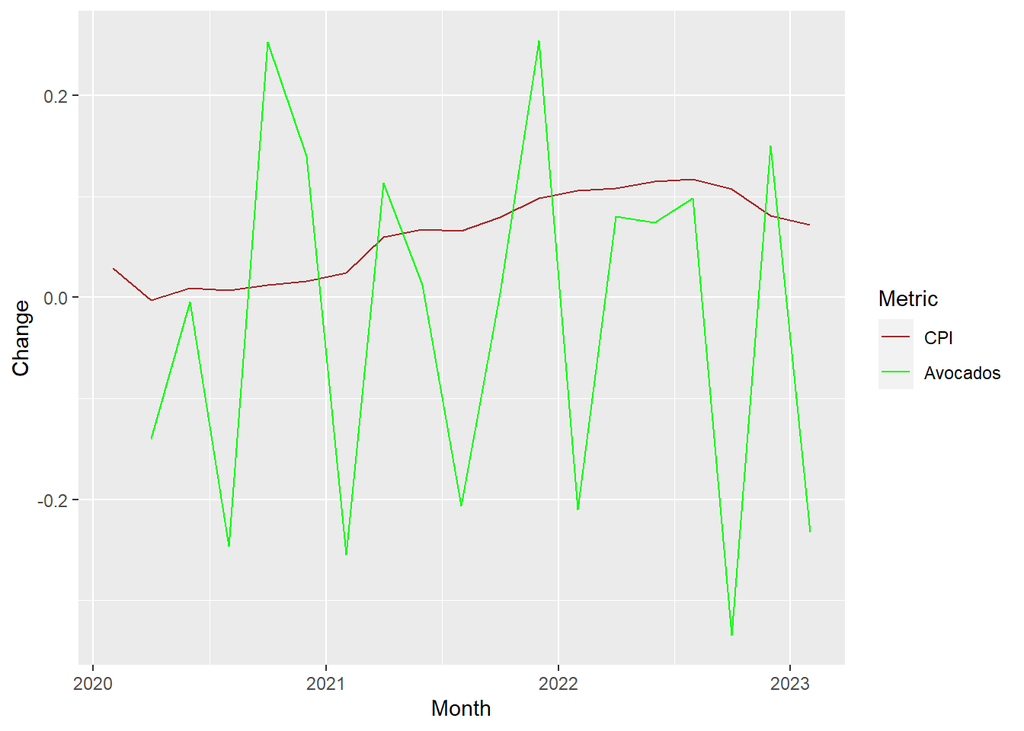

Seems all over the map for Avocados, while CPI appears to be fairly smooth. We can now move into some statistical analysis.

## Step 4: Correlation

We can compare correlation of Avocados and CPI since they are both quantitative variables. This will tell us if there is a linear change associated with a change in each variable. We can plot each against each other for a visual representation, and then do a correlation test to get a statistical value.

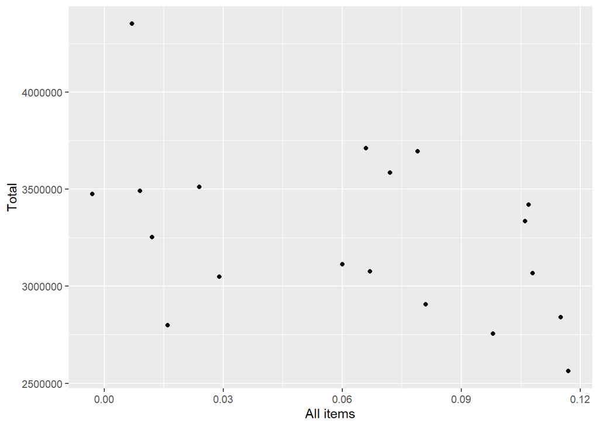

## Linear Regression of Avocado Sales, time, and CPI

We can also do linear regression on the data to see if there the amount of avocados are changing linearly and by how much against time and CPI. Plotting multiple variables gets more complicated to visualize (It would be a warped plane in this instance), so we have to rely on statistical inference exclusively.

```
##
## Call:
## lm(formula = Total ~ Month + `All items`, data = .)
##
## Residuals:
##     Min      1Q  Median      3Q     Max
## -698299 -242292  -63294  249210  837064
##
## Coefficients:
##               Estimate Std. Error t value Pr(>|t|)
## (Intercept) -3.753e+06  9.896e+06  -0.379    0.709
## Month        4.585e-03  6.222e-03   0.737    0.472
## `All items` -7.261e+06  4.421e+06  -1.642    0.120
##
## Residual standard error: 400500 on 16 degrees of freedom
## Multiple R-squared:  0.2164, Adjusted R-squared:  0.1185
## F-statistic:  2.21 on 2 and 16 DF,  p-value: 0.1421
```

This is where things actually get interesting. With very limited data there is a negative association with the total number of Avocados sold and CPI. It is not statistically significant, but this is also too small of a dataset.

## Step 6: Conclusions

From what we have done there is very little evidence to suggest that CPI is having an impact on the number of Avocados sold in Atlanta. This study is very limited by the sample size that we have. This would need to be expanded to more datapoints, perhaps by including more regions with localized CPI’s, smaller time intervals, or a longer time period.